# Risk Factor Analysis

## Outcome Variable

**Outcome Variable:** whz

## Predictor Variables

**Intervention Variable:** nhh

**Adjustment Set:**

- arm
- W_mage
- meducyrs
- feducyrs
- hhwealth_quart
- W_mhtcm
- W_mwtkg
- W_mbmi
- W_nrooms
- cleanck
- impfloor
- impsan
- safeh20
- delta_W_mage
- delta_meducyrs
- delta_feducyrs
- delta_hhwealth_quart
- delta_W_mhtcm
- delta_W_mwtkg
- delta_W_mbmi
- delta_W_nrooms
- delta_cleanck
- delta_impfloor
- delta_impsan
- delta_safeh20

## Stratifying Variables

The analysis was stratified on these variable(s):

- agecat
- studyid
- country

## Data Summary

| agecat | studyid | country | nhh | n_cell | n |
| --- | --- | --- | --- | --- | --- |
| Birth | ki1000108-IRC | INDIA | 3 or less | 52 | 343 |
| Birth | ki1000108-IRC | INDIA | 4-5 | 131 | 343 |
| Birth | ki1000108-IRC | INDIA | 6-7 | 84 | 343 |
| Birth | ki1000108-IRC | INDIA | 8+ | 76 | 343 |
| Birth | ki1017093-NIH-Birth | BANGLADESH | 3 or less | 104 | 575 |
| Birth | ki1017093-NIH-Birth | BANGLADESH | 4-5 | 244 | 575 |
| Birth | ki1017093-NIH-Birth | BANGLADESH | 6-7 | 130 | 575 |
| Birth | ki1017093-NIH-Birth | BANGLADESH | 8+ | 97 | 575 |
| Birth | ki1017093b-PROVIDE | BANGLADESH | 3 or less | 103 | 532 |
| Birth | ki1017093b-PROVIDE | BANGLADESH | 4-5 | 249 | 532 |
| Birth | ki1017093b-PROVIDE | BANGLADESH | 6-7 | 114 | 532 |
| Birth | ki1017093b-PROVIDE | BANGLADESH | 8+ | 66 | 532 |
| Birth | ki1017093c-NIH-Crypto | BANGLADESH | 3 or less | 103 | 707 |
| Birth | ki1017093c-NIH-Crypto | BANGLADESH | 4-5 | 318 | 707 |
| Birth | ki1017093c-NIH-Crypto | BANGLADESH | 6-7 | 167 | 707 |
| Birth | ki1017093c-NIH-Crypto | BANGLADESH | 8+ | 119 | 707 |
| 6 months | ki1000108-IRC | INDIA | 3 or less | 57 | 408 |
| 6 months | ki1000108-IRC | INDIA | 4-5 | 157 | 408 |
| 6 months | ki1000108-IRC | INDIA | 6-7 | 107 | 408 |
| 6 months | ki1000108-IRC | INDIA | 8+ | 87 | 408 |
| 6 months | ki1000304b-SAS-FoodSuppl | INDIA | 3 or less | 33 | 380 |
| 6 months | ki1000304b-SAS-FoodSuppl | INDIA | 4-5 | 166 | 380 |
| 6 months | ki1000304b-SAS-FoodSuppl | INDIA | 6-7 | 115 | 380 |
| 6 months | ki1000304b-SAS-FoodSuppl | INDIA | 8+ | 66 | 380 |
| 6 months | ki1017093-NIH-Birth | BANGLADESH | 3 or less | 95 | 537 |
| 6 months | ki1017093-NIH-Birth | BANGLADESH | 4-5 | 227 | 537 |
| 6 months | ki1017093-NIH-Birth | BANGLADESH | 6-7 | 128 | 537 |
| 6 months | ki1017093-NIH-Birth | BANGLADESH | 8+ | 87 | 537 |
| 6 months | ki1017093b-PROVIDE | BANGLADESH | 3 or less | 105 | 603 |
| 6 months | ki1017093b-PROVIDE | BANGLADESH | 4-5 | 289 | 603 |
| 6 months | ki1017093b-PROVIDE | BANGLADESH | 6-7 | 130 | 603 |
| 6 months | ki1017093b-PROVIDE | BANGLADESH | 8+ | 79 | 603 |
| 6 months | ki1017093c-NIH-Crypto | BANGLADESH | 3 or less | 104 | 715 |
| 6 months | ki1017093c-NIH-Crypto | BANGLADESH | 4-5 | 326 | 715 |
| 6 months | ki1017093c-NIH-Crypto | BANGLADESH | 6-7 | 170 | 715 |
| 6 months | ki1017093c-NIH-Crypto | BANGLADESH | 8+ | 115 | 715 |
| 6 months | ki1148112-LCNI-5 | MALAWI | 3 or less | 224 | 816 |
| 6 months | ki1148112-LCNI-5 | MALAWI | 4-5 | 340 | 816 |
| 6 months | ki1148112-LCNI-5 | MALAWI | 6-7 | 182 | 816 |
| 6 months | ki1148112-LCNI-5 | MALAWI | 8+ | 70 | 816 |
| 24 months | ki1000108-IRC | INDIA | 3 or less | 58 | 409 |
| 24 months | ki1000108-IRC | INDIA | 4-5 | 158 | 409 |
| 24 months | ki1000108-IRC | INDIA | 6-7 | 107 | 409 |
| 24 months | ki1000108-IRC | INDIA | 8+ | 86 | 409 |
| 24 months | ki1017093-NIH-Birth | BANGLADESH | 3 or less | 74 | 428 |
| 24 months | ki1017093-NIH-Birth | BANGLADESH | 4-5 | 184 | 428 |
| 24 months | ki1017093-NIH-Birth | BANGLADESH | 6-7 | 100 | 428 |
| 24 months | ki1017093-NIH-Birth | BANGLADESH | 8+ | 70 | 428 |
| 24 months | ki1017093b-PROVIDE | BANGLADESH | 3 or less | 106 | 579 |
| 24 months | ki1017093b-PROVIDE | BANGLADESH | 4-5 | 273 | 579 |
| 24 months | ki1017093b-PROVIDE | BANGLADESH | 6-7 | 117 | 579 |
| 24 months | ki1017093b-PROVIDE | BANGLADESH | 8+ | 83 | 579 |
| 24 months | ki1017093c-NIH-Crypto | BANGLADESH | 3 or less | 69 | 514 |
| 24 months | ki1017093c-NIH-Crypto | BANGLADESH | 4-5 | 232 | 514 |
| 24 months | ki1017093c-NIH-Crypto | BANGLADESH | 6-7 | 130 | 514 |
| 24 months | ki1017093c-NIH-Crypto | BANGLADESH | 8+ | 83 | 514 |
| 24 months | ki1148112-LCNI-5 | MALAWI | 3 or less | 157 | 558 |
| 24 months | ki1148112-LCNI-5 | MALAWI | 4-5 | 230 | 558 |
| 24 months | ki1148112-LCNI-5 | MALAWI | 6-7 | 123 | 558 |
| 24 months | ki1148112-LCNI-5 | MALAWI | 8+ | 48 | 558 |

The following strata were considered:

- agecat: 24 months, studyid: ki1000108-IRC, country: INDIA
- agecat: 24 months, studyid: ki1017093-NIH-Birth, country: BANGLADESH
- agecat: 24 months, studyid: ki1017093b-PROVIDE, country: BANGLADESH
- agecat: 24 months, studyid: ki1017093c-NIH-Crypto, country: BANGLADESH
- agecat: 24 months, studyid: ki1148112-LCNI-5, country: MALAWI
- agecat: 6 months, studyid: ki1000108-IRC, country: INDIA
- agecat: 6 months, studyid: ki1000304b-SAS-FoodSuppl, country: INDIA
- agecat: 6 months, studyid: ki1017093-NIH-Birth, country: BANGLADESH
- agecat: 6 months, studyid: ki1017093b-PROVIDE, country: BANGLADESH
- agecat: 6 months, studyid: ki1017093c-NIH-Crypto, country: BANGLADESH
- agecat: 6 months, studyid: ki1148112-LCNI-5, country: MALAWI
- agecat: Birth, studyid: ki1000108-IRC, country: INDIA
- agecat: Birth, studyid: ki1017093-NIH-Birth, country: BANGLADESH
- agecat: Birth, studyid: ki1017093b-PROVIDE, country: BANGLADESH
- agecat: Birth, studyid: ki1017093c-NIH-Crypto, country: BANGLADESH

## Methods Detail

We’re interested in the causal parameters $E[Y_a]$ for all values of $a \in \mathcal{A}$. These parameters represent the mean outcome if, possibly contrary to fact, we intervened to set all units to have $A=a$. Under the randomization and positivity assumptions, these are identified by the statistical parameters $\psi_a=E_W[E_{Y|A,W}(Y|A=a,W)]$. In addition, we’re interested in the mean of $Y$, $E[Y]$ under no intervention (the observed mean). We will estimate these parameters by using SuperLearner to fit the relevant likelihood factors – $E_{Y|A,W}(Y|A=a,W)$ and $p(A=a|W)$, and then updating our likelihood fit using a joint TMLE.

For unadjusted analyses ($W=\{\}$), initial likelihoods were estimated using Lrnr_glm to estimate the simple $E(Y|A)$ and Lrnr_mean to estimate $p(A)$. For adjusted analyses, a small library containing Lrnr_glmnet, Lrnr_xgboost, and Lrnr_mean was used.

Having estimated these parameters, we will then use the delta method to estimate relative risks and attributable risks relative to a prespecified baseline level of $A$.

# Results Detail

## Results Plots

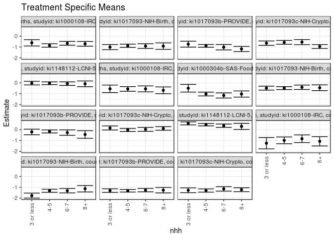

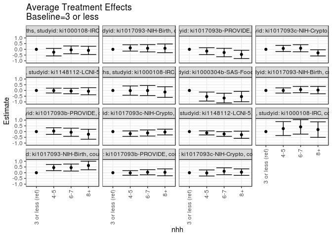

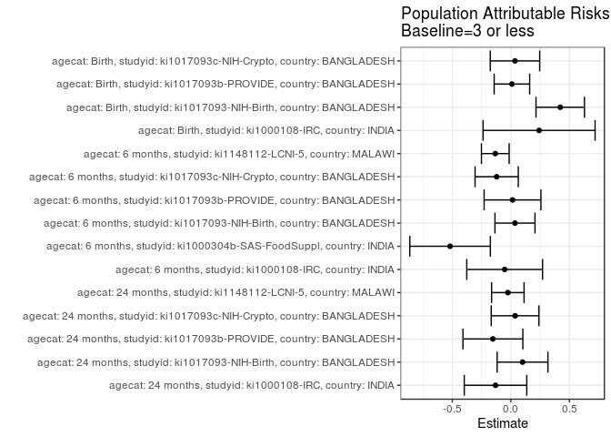

## Results Table

### Parameter: TSM

| agecat | studyid | country | intervention_level | baseline_level | estimate | ci_lower | ci_upper |
| --- | --- | --- | --- | --- | --- | --- | --- |
| Birth | ki1000108-IRC | INDIA | 3 or less | NA | -1.2517198 | -1.7748928 | -0.7285468 |
| Birth | ki1000108-IRC | INDIA | 4-5 | NA | -0.9902459 | -1.3001751 | -0.6803168 |
| Birth | ki1000108-IRC | INDIA | 6-7 | NA | -0.8405974 | -1.1937894 | -0.4874054 |
| Birth | ki1000108-IRC | INDIA | 8+ | NA | -1.0761464 | -1.5062769 | -0.6460160 |
| Birth | ki1017093-NIH-Birth | BANGLADESH | 3 or less | NA | -1.7716523 | -1.9999903 | -1.5433143 |
| Birth | ki1017093-NIH-Birth | BANGLADESH | 4-5 | NA | -1.3225547 | -1.4620239 | -1.1830855 |
| Birth | ki1017093-NIH-Birth | BANGLADESH | 6-7 | NA | -1.3227883 | -1.5253171 | -1.1202596 |
| Birth | ki1017093-NIH-Birth | BANGLADESH | 8+ | NA | -1.1399397 | -1.4357860 | -0.8440933 |
| Birth | ki1017093b-PROVIDE | BANGLADESH | 3 or less | NA | -1.3075604 | -1.4716371 | -1.1434837 |
| Birth | ki1017093b-PROVIDE | BANGLADESH | 4-5 | NA | -1.3274465 | -1.4462673 | -1.2086258 |
| Birth | ki1017093b-PROVIDE | BANGLADESH | 6-7 | NA | -1.2671660 | -1.4218720 | -1.1124601 |
| Birth | ki1017093b-PROVIDE | BANGLADESH | 8+ | NA | -1.2737363 | -1.5266201 | -1.0208526 |
| Birth | ki1017093c-NIH-Crypto | BANGLADESH | 3 or less | NA | -1.2794884 | -1.5001109 | -1.0588659 |
| Birth | ki1017093c-NIH-Crypto | BANGLADESH | 4-5 | NA | -1.3037740 | -1.4511139 | -1.1564342 |
| Birth | ki1017093c-NIH-Crypto | BANGLADESH | 6-7 | NA | -1.1518312 | -1.3583247 | -0.9453376 |
| Birth | ki1017093c-NIH-Crypto | BANGLADESH | 8+ | NA | -1.2269802 | -1.4065118 | -1.0474485 |
| 6 months | ki1000108-IRC | INDIA | 3 or less | NA | -0.5460102 | -0.8910939 | -0.2009266 |
| 6 months | ki1000108-IRC | INDIA | 4-5 | NA | -0.5584246 | -0.7728220 | -0.3440272 |
| 6 months | ki1000108-IRC | INDIA | 6-7 | NA | -0.5528705 | -0.8257650 | -0.2799760 |
| 6 months | ki1000108-IRC | INDIA | 8+ | NA | -0.6850124 | -0.9955007 | -0.3745242 |
| 6 months | ki1000304b-SAS-FoodSuppl | INDIA | 3 or less | NA | -0.4930519 | -0.8444916 | -0.1416122 |
| 6 months | ki1000304b-SAS-FoodSuppl | INDIA | 4-5 | NA | -1.0244502 | -1.2002208 | -0.8486796 |
| 6 months | ki1000304b-SAS-FoodSuppl | INDIA | 6-7 | NA | -1.1571092 | -1.3924192 | -0.9217993 |
| 6 months | ki1000304b-SAS-FoodSuppl | INDIA | 8+ | NA | -1.0266406 | -1.3096537 | -0.7436275 |
| 6 months | ki1017093-NIH-Birth | BANGLADESH | 3 or less | NA | -0.4826228 | -0.6652706 | -0.2999751 |
| 6 months | ki1017093-NIH-Birth | BANGLADESH | 4-5 | NA | -0.4825474 | -0.6193628 | -0.3457319 |
| 6 months | ki1017093-NIH-Birth | BANGLADESH | 6-7 | NA | -0.4057728 | -0.6092533 | -0.2022922 |
| 6 months | ki1017093-NIH-Birth | BANGLADESH | 8+ | NA | -0.4492995 | -0.7142121 | -0.1843869 |
| 6 months | ki1017093b-PROVIDE | BANGLADESH | 3 or less | NA | -0.2132609 | -0.4711153 | 0.0445934 |
| 6 months | ki1017093b-PROVIDE | BANGLADESH | 4-5 | NA | -0.1677215 | -0.3050003 | -0.0304426 |
| 6 months | ki1017093b-PROVIDE | BANGLADESH | 6-7 | NA | -0.2706769 | -0.5183373 | -0.0230165 |
| 6 months | ki1017093b-PROVIDE | BANGLADESH | 8+ | NA | -0.4468610 | -0.7973210 | -0.0964010 |
| 6 months | ki1017093c-NIH-Crypto | BANGLADESH | 3 or less | NA | 0.1507866 | -0.0386456 | 0.3402188 |
| 6 months | ki1017093c-NIH-Crypto | BANGLADESH | 4-5 | NA | -0.0294291 | -0.1741241 | 0.1152660 |
| 6 months | ki1017093c-NIH-Crypto | BANGLADESH | 6-7 | NA | 0.0270729 | -0.1555614 | 0.2097071 |
| 6 months | ki1017093c-NIH-Crypto | BANGLADESH | 8+ | NA | 0.1099345 | -0.0570728 | 0.2769417 |
| 6 months | ki1148112-LCNI-5 | MALAWI | 3 or less | NA | 0.5746189 | 0.4358543 | 0.7133835 |
| 6 months | ki1148112-LCNI-5 | MALAWI | 4-5 | NA | 0.4588864 | 0.3464628 | 0.5713101 |
| 6 months | ki1148112-LCNI-5 | MALAWI | 6-7 | NA | 0.3638870 | 0.2100126 | 0.5177614 |
| 6 months | ki1148112-LCNI-5 | MALAWI | 8+ | NA | 0.2970892 | 0.0122901 | 0.5818883 |
| 24 months | ki1000108-IRC | INDIA | 3 or less | NA | -0.6147578 | -0.9027154 | -0.3268002 |
| 24 months | ki1000108-IRC | INDIA | 4-5 | NA | -0.8637682 | -1.0224927 | -0.7050437 |
| 24 months | ki1000108-IRC | INDIA | 6-7 | NA | -0.6607026 | -0.8376635 | -0.4837416 |
| 24 months | ki1000108-IRC | INDIA | 8+ | NA | -0.7061642 | -0.9232698 | -0.4890585 |
| 24 months | ki1017093-NIH-Birth | BANGLADESH | 3 or less | NA | -1.0112948 | -1.2479451 | -0.7746445 |
| 24 months | ki1017093-NIH-Birth | BANGLADESH | 4-5 | NA | -0.8877619 | -1.0358827 | -0.7396410 |
| 24 months | ki1017093-NIH-Birth | BANGLADESH | 6-7 | NA | -0.9176784 | -1.1312712 | -0.7040857 |
| 24 months | ki1017093-NIH-Birth | BANGLADESH | 8+ | NA | -0.9220795 | -1.2207801 | -0.6233789 |
| 24 months | ki1017093b-PROVIDE | BANGLADESH | 3 or less | NA | -0.7394038 | -1.0112085 | -0.4675991 |
| 24 months | ki1017093b-PROVIDE | BANGLADESH | 4-5 | NA | -0.8965288 | -1.0266243 | -0.7664333 |
| 24 months | ki1017093b-PROVIDE | BANGLADESH | 6-7 | NA | -1.0171788 | -1.2670794 | -0.7672782 |
| 24 months | ki1017093b-PROVIDE | BANGLADESH | 8+ | NA | -1.1836917 | -1.4207791 | -0.9466044 |
| 24 months | ki1017093c-NIH-Crypto | BANGLADESH | 3 or less | NA | -0.6464968 | -0.8497915 | -0.4432021 |
| 24 months | ki1017093c-NIH-Crypto | BANGLADESH | 4-5 | NA | -0.5706122 | -0.7470373 | -0.3941871 |
| 24 months | ki1017093c-NIH-Crypto | BANGLADESH | 6-7 | NA | -0.5499373 | -0.7843293 | -0.3155452 |
| 24 months | ki1017093c-NIH-Crypto | BANGLADESH | 8+ | NA | -0.9561500 | -1.1345351 | -0.7777649 |
| 24 months | ki1148112-LCNI-5 | MALAWI | 3 or less | NA | -0.0219719 | -0.1895620 | 0.1456183 |
| 24 months | ki1148112-LCNI-5 | MALAWI | 4-5 | NA | -0.0326265 | -0.1605630 | 0.0953099 |
| 24 months | ki1148112-LCNI-5 | MALAWI | 6-7 | NA | -0.0695002 | -0.2366970 | 0.0976966 |
| 24 months | ki1148112-LCNI-5 | MALAWI | 8+ | NA | -0.0891596 | -0.3524674 | 0.1741481 |

### Parameter: E(Y)

| agecat | studyid | country | intervention_level | baseline_level | estimate | ci_lower | ci_upper |
| --- | --- | --- | --- | --- | --- | --- | --- |
| Birth | ki1000108-IRC | INDIA | NA | NA | -1.0105831 | -1.1973019 | -0.8238643 |
| Birth | ki1017093-NIH-Birth | BANGLADESH | NA | NA | -1.3499217 | -1.4444634 | -1.2553801 |
| Birth | ki1017093b-PROVIDE | BANGLADESH | NA | NA | -1.2984586 | -1.3752758 | -1.2216415 |
| Birth | ki1017093c-NIH-Crypto | BANGLADESH | NA | NA | -1.2441513 | -1.3281130 | -1.1601897 |
| 6 months | ki1000108-IRC | INDIA | NA | NA | -0.5989297 | -0.7344491 | -0.4634104 |
| 6 months | ki1000304b-SAS-FoodSuppl | INDIA | NA | NA | -1.0121579 | -1.1280429 | -0.8962729 |
| 6 months | ki1017093-NIH-Birth | BANGLADESH | NA | NA | -0.4474038 | -0.5378167 | -0.3569909 |
| 6 months | ki1017093b-PROVIDE | BANGLADESH | NA | NA | -0.1990907 | -0.2817968 | -0.1163845 |
| 6 months | ki1017093c-NIH-Crypto | BANGLADESH | NA | NA | 0.0297622 | -0.0491685 | 0.1086930 |
| 6 months | ki1148112-LCNI-5 | MALAWI | NA | NA | 0.4417647 | 0.3702742 | 0.5132552 |
| 24 months | ki1000108-IRC | INDIA | NA | NA | -0.7458150 | -0.8368180 | -0.6548120 |
| 24 months | ki1017093-NIH-Birth | BANGLADESH | NA | NA | -0.9115790 | -1.0095022 | -0.8136559 |
| 24 months | ki1017093b-PROVIDE | BANGLADESH | NA | NA | -0.8928670 | -0.9755153 | -0.8102187 |
| 24 months | ki1017093c-NIH-Crypto | BANGLADESH | NA | NA | -0.6103502 | -0.7050157 | -0.5156847 |
| 24 months | ki1148112-LCNI-5 | MALAWI | NA | NA | -0.0477867 | -0.1301103 | 0.0345368 |

### Parameter: ATE

| agecat | studyid | country | intervention_level | baseline_level | estimate | ci_lower | ci_upper |
| --- | --- | --- | --- | --- | --- | --- | --- |
| Birth | ki1000108-IRC | INDIA | 3 or less | 3 or less | 0.0000000 | 0.0000000 | 0.0000000 |
| Birth | ki1000108-IRC | INDIA | 4-5 | 3 or less | 0.2614738 | -0.3464668 | 0.8694145 |
| Birth | ki1000108-IRC | INDIA | 6-7 | 3 or less | 0.4111224 | -0.2195358 | 1.0417807 |
| Birth | ki1000108-IRC | INDIA | 8+ | 3 or less | 0.1755733 | -0.5040598 | 0.8552065 |
| Birth | ki1017093-NIH-Birth | BANGLADESH | 3 or less | 3 or less | 0.0000000 | 0.0000000 | 0.0000000 |
| Birth | ki1017093-NIH-Birth | BANGLADESH | 4-5 | 3 or less | 0.4490976 | 0.1811778 | 0.7170174 |
| Birth | ki1017093-NIH-Birth | BANGLADESH | 6-7 | 3 or less | 0.4488639 | 0.1431237 | 0.7546042 |
| Birth | ki1017093-NIH-Birth | BANGLADESH | 8+ | 3 or less | 0.6317126 | 0.2574538 | 1.0059715 |
| Birth | ki1017093b-PROVIDE | BANGLADESH | 3 or less | 3 or less | 0.0000000 | 0.0000000 | 0.0000000 |
| Birth | ki1017093b-PROVIDE | BANGLADESH | 4-5 | 3 or less | -0.0198861 | -0.2226641 | 0.1828918 |
| Birth | ki1017093b-PROVIDE | BANGLADESH | 6-7 | 3 or less | 0.0403944 | -0.1846865 | 0.2654752 |
| Birth | ki1017093b-PROVIDE | BANGLADESH | 8+ | 3 or less | 0.0338241 | -0.2671078 | 0.3347559 |
| Birth | ki1017093c-NIH-Crypto | BANGLADESH | 3 or less | 3 or less | 0.0000000 | 0.0000000 | 0.0000000 |
| Birth | ki1017093c-NIH-Crypto | BANGLADESH | 4-5 | 3 or less | -0.0242857 | -0.2889701 | 0.2403987 |
| Birth | ki1017093c-NIH-Crypto | BANGLADESH | 6-7 | 3 or less | 0.1276572 | -0.1742021 | 0.4295165 |
| Birth | ki1017093c-NIH-Crypto | BANGLADESH | 8+ | 3 or less | 0.0525082 | -0.2313973 | 0.3364137 |
| 6 months | ki1000108-IRC | INDIA | 3 or less | 3 or less | 0.0000000 | 0.0000000 | 0.0000000 |
| 6 months | ki1000108-IRC | INDIA | 4-5 | 3 or less | -0.0124144 | -0.4182097 | 0.3933810 |
| 6 months | ki1000108-IRC | INDIA | 6-7 | 3 or less | -0.0068602 | -0.4450389 | 0.4313184 |
| 6 months | ki1000108-IRC | INDIA | 8+ | 3 or less | -0.1390022 | -0.6050403 | 0.3270360 |
| 6 months | ki1000304b-SAS-FoodSuppl | INDIA | 3 or less | 3 or less | 0.0000000 | 0.0000000 | 0.0000000 |
| 6 months | ki1000304b-SAS-FoodSuppl | INDIA | 4-5 | 3 or less | -0.5313983 | -0.9241998 | -0.1385968 |
| 6 months | ki1000304b-SAS-FoodSuppl | INDIA | 6-7 | 3 or less | -0.6640573 | -1.0873111 | -0.2408035 |
| 6 months | ki1000304b-SAS-FoodSuppl | INDIA | 8+ | 3 or less | -0.5335887 | -0.9844858 | -0.0826916 |
| 6 months | ki1017093-NIH-Birth | BANGLADESH | 3 or less | 3 or less | 0.0000000 | 0.0000000 | 0.0000000 |
| 6 months | ki1017093-NIH-Birth | BANGLADESH | 4-5 | 3 or less | 0.0000754 | -0.2271648 | 0.2273157 |
| 6 months | ki1017093-NIH-Birth | BANGLADESH | 6-7 | 3 or less | 0.0768501 | -0.1955403 | 0.3492405 |
| 6 months | ki1017093-NIH-Birth | BANGLADESH | 8+ | 3 or less | 0.0333233 | -0.2876069 | 0.3542535 |
| 6 months | ki1017093b-PROVIDE | BANGLADESH | 3 or less | 3 or less | 0.0000000 | 0.0000000 | 0.0000000 |
| 6 months | ki1017093b-PROVIDE | BANGLADESH | 4-5 | 3 or less | 0.0455395 | -0.2460494 | 0.3371283 |
| 6 months | ki1017093b-PROVIDE | BANGLADESH | 6-7 | 3 or less | -0.0574160 | -0.4145241 | 0.2996922 |
| 6 months | ki1017093b-PROVIDE | BANGLADESH | 8+ | 3 or less | -0.2336001 | -0.6678284 | 0.2006283 |
| 6 months | ki1017093c-NIH-Crypto | BANGLADESH | 3 or less | 3 or less | 0.0000000 | 0.0000000 | 0.0000000 |
| 6 months | ki1017093c-NIH-Crypto | BANGLADESH | 4-5 | 3 or less | -0.1802156 | -0.4186516 | 0.0582203 |
| 6 months | ki1017093c-NIH-Crypto | BANGLADESH | 6-7 | 3 or less | -0.1237137 | -0.3873995 | 0.1399720 |
| 6 months | ki1017093c-NIH-Crypto | BANGLADESH | 8+ | 3 or less | -0.0408521 | -0.2935794 | 0.2118752 |
| 6 months | ki1148112-LCNI-5 | MALAWI | 3 or less | 3 or less | 0.0000000 | 0.0000000 | 0.0000000 |
| 6 months | ki1148112-LCNI-5 | MALAWI | 4-5 | 3 or less | -0.1157325 | -0.2943216 | 0.0628567 |
| 6 months | ki1148112-LCNI-5 | MALAWI | 6-7 | 3 or less | -0.2107319 | -0.4169201 | -0.0045437 |
| 6 months | ki1148112-LCNI-5 | MALAWI | 8+ | 3 or less | -0.2775297 | -0.5940300 | 0.0389706 |
| 24 months | ki1000108-IRC | INDIA | 3 or less | 3 or less | 0.0000000 | 0.0000000 | 0.0000000 |
| 24 months | ki1000108-IRC | INDIA | 4-5 | 3 or less | -0.2490104 | -0.5783508 | 0.0803300 |
| 24 months | ki1000108-IRC | INDIA | 6-7 | 3 or less | -0.0459448 | -0.3843948 | 0.2925052 |
| 24 months | ki1000108-IRC | INDIA | 8+ | 3 or less | -0.0914064 | -0.4550537 | 0.2722409 |
| 24 months | ki1017093-NIH-Birth | BANGLADESH | 3 or less | 3 or less | 0.0000000 | 0.0000000 | 0.0000000 |
| 24 months | ki1017093-NIH-Birth | BANGLADESH | 4-5 | 3 or less | 0.1235330 | -0.1536186 | 0.4006845 |
| 24 months | ki1017093-NIH-Birth | BANGLADESH | 6-7 | 3 or less | 0.0936164 | -0.2237575 | 0.4109903 |
| 24 months | ki1017093-NIH-Birth | BANGLADESH | 8+ | 3 or less | 0.0892153 | -0.2903306 | 0.4687612 |
| 24 months | ki1017093b-PROVIDE | BANGLADESH | 3 or less | 3 or less | 0.0000000 | 0.0000000 | 0.0000000 |
| 24 months | ki1017093b-PROVIDE | BANGLADESH | 4-5 | 3 or less | -0.1571250 | -0.4581566 | 0.1439067 |
| 24 months | ki1017093b-PROVIDE | BANGLADESH | 6-7 | 3 or less | -0.2777750 | -0.6461147 | 0.0905646 |
| 24 months | ki1017093b-PROVIDE | BANGLADESH | 8+ | 3 or less | -0.4442879 | -0.8039942 | -0.0845817 |
| 24 months | ki1017093c-NIH-Crypto | BANGLADESH | 3 or less | 3 or less | 0.0000000 | 0.0000000 | 0.0000000 |
| 24 months | ki1017093c-NIH-Crypto | BANGLADESH | 4-5 | 3 or less | 0.0758846 | -0.1932984 | 0.3450675 |
| 24 months | ki1017093c-NIH-Crypto | BANGLADESH | 6-7 | 3 or less | 0.0965595 | -0.2118856 | 0.4050046 |
| 24 months | ki1017093c-NIH-Crypto | BANGLADESH | 8+ | 3 or less | -0.3096532 | -0.5809338 | -0.0383727 |
| 24 months | ki1148112-LCNI-5 | MALAWI | 3 or less | 3 or less | 0.0000000 | 0.0000000 | 0.0000000 |
| 24 months | ki1148112-LCNI-5 | MALAWI | 4-5 | 3 or less | -0.0106547 | -0.2219648 | 0.2006555 |
| 24 months | ki1148112-LCNI-5 | MALAWI | 6-7 | 3 or less | -0.0475283 | -0.2848629 | 0.1898063 |
| 24 months | ki1148112-LCNI-5 | MALAWI | 8+ | 3 or less | -0.0671878 | -0.3783244 | 0.2439488 |

### Parameter: PAR

| agecat | studyid | country | intervention_level | baseline_level | estimate | ci_lower | ci_upper |
| --- | --- | --- | --- | --- | --- | --- | --- |
| Birth | ki1000108-IRC | INDIA | 3 or less | NA | 0.2411367 | -0.2373772 | 0.7196506 |
| Birth | ki1017093-NIH-Birth | BANGLADESH | 3 or less | NA | 0.4217306 | 0.2147486 | 0.6287125 |
| Birth | ki1017093b-PROVIDE | BANGLADESH | 3 or less | NA | 0.0091017 | -0.1425155 | 0.1607190 |
| Birth | ki1017093c-NIH-Crypto | BANGLADESH | 3 or less | NA | 0.0353370 | -0.1757207 | 0.2463948 |
| 6 months | ki1000108-IRC | INDIA | 3 or less | NA | -0.0529195 | -0.3766526 | 0.2708136 |
| 6 months | ki1000304b-SAS-FoodSuppl | INDIA | 3 or less | NA | -0.5191060 | -0.8632534 | -0.1749585 |
| 6 months | ki1017093-NIH-Birth | BANGLADESH | 3 or less | NA | 0.0352190 | -0.1357889 | 0.2062270 |
| 6 months | ki1017093b-PROVIDE | BANGLADESH | 3 or less | NA | 0.0141703 | -0.2284395 | 0.2567800 |
| 6 months | ki1017093c-NIH-Crypto | BANGLADESH | 3 or less | NA | -0.1210244 | -0.3056489 | 0.0636002 |
| 6 months | ki1148112-LCNI-5 | MALAWI | 3 or less | NA | -0.1328542 | -0.2512608 | -0.0144476 |
| 24 months | ki1000108-IRC | INDIA | 3 or less | NA | -0.1310572 | -0.3981440 | 0.1360295 |
| 24 months | ki1017093-NIH-Birth | BANGLADESH | 3 or less | NA | 0.0997158 | -0.1172690 | 0.3167005 |
| 24 months | ki1017093b-PROVIDE | BANGLADESH | 3 or less | NA | -0.1534632 | -0.4093724 | 0.1024460 |
| 24 months | ki1017093c-NIH-Crypto | BANGLADESH | 3 or less | NA | 0.0361466 | -0.1676638 | 0.2399570 |
| 24 months | ki1148112-LCNI-5 | MALAWI | 3 or less | NA | -0.0258149 | -0.1645346 | 0.1129049 |